# GAM workshop

Lusia

2024-11-04

Using the built-in CO2 dataset in R, which gives uptake of CO2 in grasses under varying CO2 concentrations, with plants from two locations (Mississippi and Quebec) and two temp treatments; 12 plants, 7 CO2 concentrations for each plant

The default CO2 plant variable is ordered; This recodes it to an unordered factor (see main text for why) GAM for non-linear relationship Spline and basis funtions## Weight of basis determine spline function## Choose values for each coefficient to maximize the likelihood Penaltized likelihood -to decrease wiggliness Lambda is based on AIC G… normally REML Effective degree of freedom is always lower than basis complexity Therefore, k should be large enough Too large k has high computational cost Check choice of k with gam.check(), information about residual and p-value etc

plot CO2 uptake vs. CO2 concentration for each plant

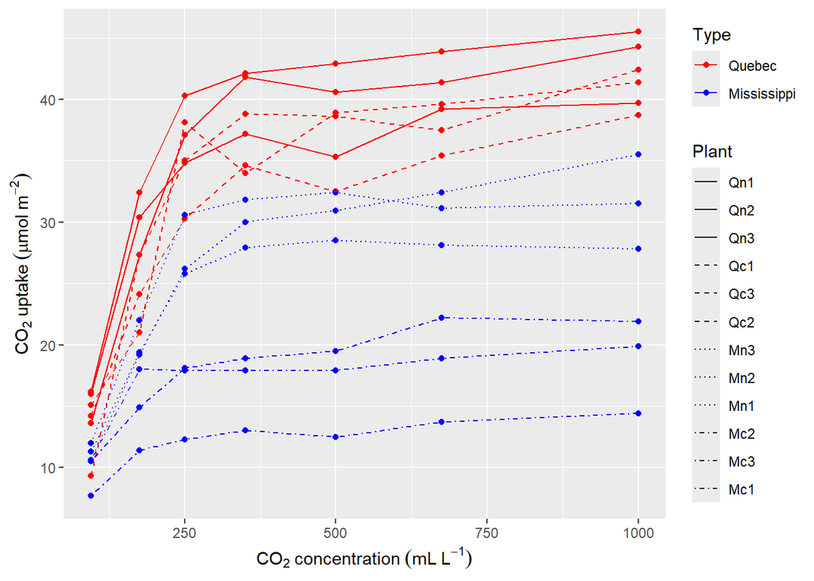

model log uptake as a function of two smoothers: thin plate spline of log concentration and RE for individual-plant-specific intercepts

plot the default gratia plot for the CO2 model

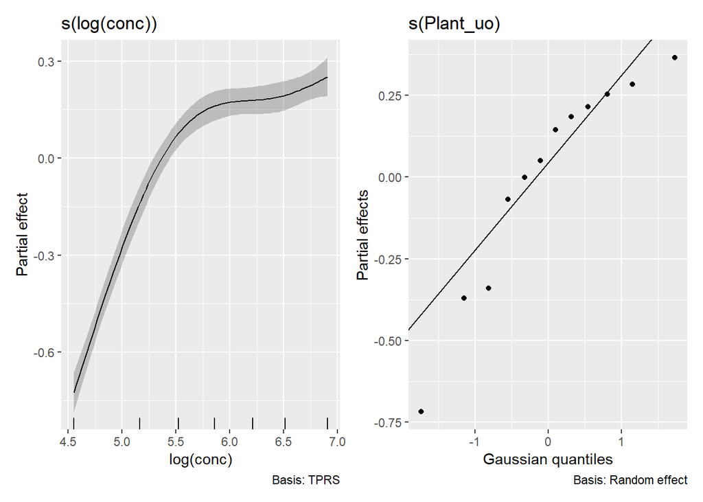

left: estimated smoother for effect log CO2 concentration on CO2 uptake right: QQ plot of the estimated random effects vs. Gaussian quantiles

```r
summary(CO2_mod1)
```

```
##
## Family: gaussian
## Link function: identity
##
## Formula:
## log(uptake) ~ s(log(conc), k = 5, bs = "tp") + s(Plant_uo, k = 12,
##     bs = "re")
##
## Parametric coefficients:
##             Estimate Std. Error t value Pr(>|t|)
## (Intercept)  3.20914    0.09497   33.79   <2e-16 ***
## ---
## Signif. codes:  0 '***' 0.001 '**' 0.01 '*' 0.05 '.' 0.1 ' ' 1
##
## Approximate significance of smooth terms:
##                 edf Ref.df      F p-value
## s(log(conc))  3.654  3.926 184.56  <2e-16 ***
## s(Plant_uo)  10.829 11.000  63.36  <2e-16 ***
## ---
## Signif. codes:  0 '***' 0.001 '**' 0.01 '*' 0.05 '.' 0.1 ' ' 1
##
## R-sq.(adj) =  0.945   Deviance explained = 95.4%
## -REML = -34.18  Scale est. = 0.011771  n = 84
```

Interpreting the summary edfs represent complexity of the smooth; edf = 1 is a straight line, higher edfs mean more wiggly

Interpretation of significance: a significant smooth is one where you can’t draw a horizontal line through the 95% CI high edf =/= significance, and vice versa a smooth can be linear and significant, non-linear and non-significant, or one of each

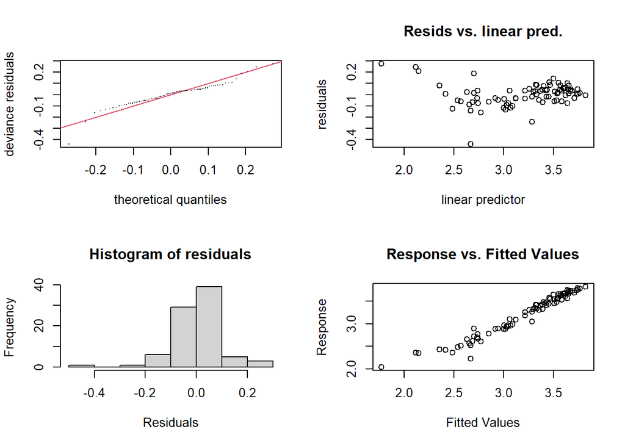

```
##
## Method: REML   Optimizer: outer newton
## full convergence after 6 iterations.
## Gradient range [-2.621328e-06,1.420512e-06]
## (score -34.17982 & scale 0.01177095).
## Hessian positive definite, eigenvalue range [1.30297,41.84635].
## Model rank =  17 / 17
##
## Basis dimension (k) checking results. Low p-value (k-index<1) may
## indicate that k is too low, especially if edf is close to k'.
##
##                 k'   edf k-index p-value
## s(log(conc))  4.00  3.65    0.67  <2e-16 ***
## s(Plant_uo)  12.00 10.83      NA      NA
## ---
## Signif. codes:  0 '***' 0.001 '**' 0.01 '*' 0.05 '.' 0.1 ' ' 1
```

```r
gam.check(CO2_mod1)
```

makes 4 plots, scroll through them (qq plot, residuals vs. linear predictor, histogram of resids, response vs. fitted) alternate form of the 4 plots from gratia package:

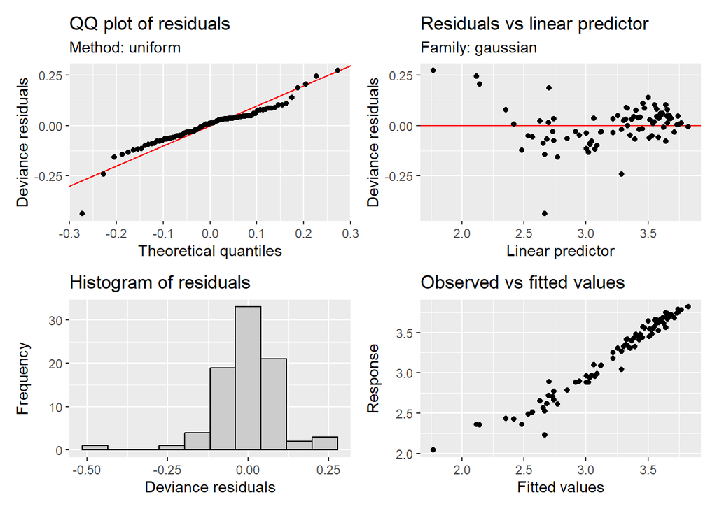

just the k part of gam.check

```
##              k'       edf   k-index p-value
## s(log(conc))  4  3.653799 0.6689691       0
## s(Plant_uo)  12 10.829087        NA      NA
```

k for log concentration smooth is probably too low

```
##
##   95  175  250  350  500  675 1000
##   12   12   12   12   12   12   12
```

but there are only 7 unique values of concentration, so k can be no larger than 7 Setup prediction data (all possible concentration values for all individual plants) make the prediction, add this and a column of standard errors to the prediction data.frame. Predictions are on the log scale.

Plot back-transformed model predictions of CO2 uptake by concentration for each plant

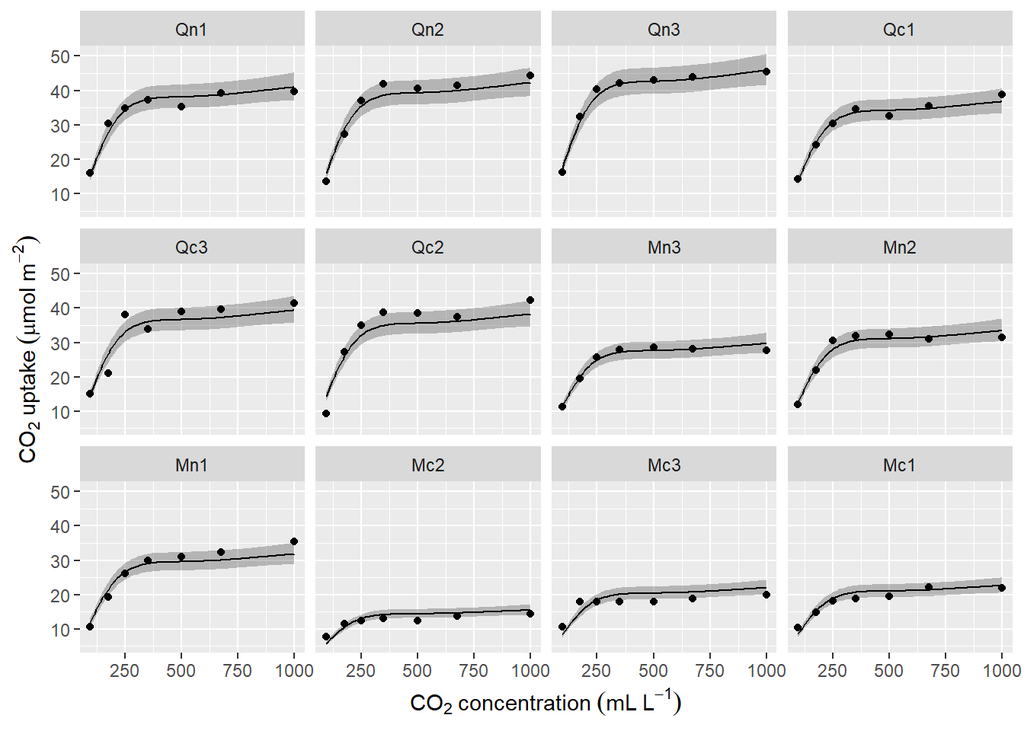

different intercepts but same shape for all plants functional responses among plants are similar, but model doesn’t capture all the patterns e.g. it underestimates for plant Qc2 fit another model adding on individual-plant-level smoothers allows shape of the uptake vs. concentration curve to vary between plants (but same wiggliness)

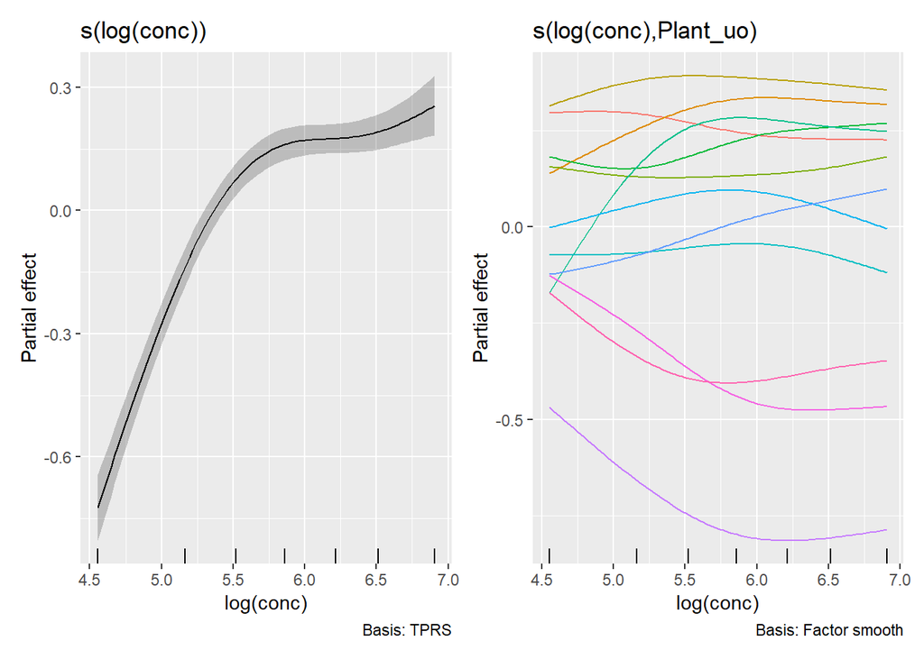

```r
draw(CO2_mod2)
```

```r
summary(CO2_mod2)
```

```
##
## Family: gaussian
## Link function: identity
##
## Formula:
## log(uptake) ~ s(log(conc), k = 5, m = 2) + s(log(conc), Plant_uo,
##     k = 5, bs = "fs", m = 2)
##
## Parametric coefficients:
##             Estimate Std. Error t value Pr(>|t|)
## (Intercept)  3.20914    0.09531   33.67   <2e-16 ***
## ---
## Signif. codes:  0 '***' 0.001 '**' 0.01 '*' 0.05 '.' 0.1 ' ' 1
##
## Approximate significance of smooth terms:
##                          edf Ref.df     F p-value
## s(log(conc))           3.845  3.948 83.57  <2e-16 ***
## s(log(conc),Plant_uo) 35.960 58.000 48.74  <2e-16 ***
## ---
## Signif. codes:  0 '***' 0.001 '**' 0.01 '*' 0.05 '.' 0.1 ' ' 1
##
## R-sq.(adj) =  0.985   Deviance explained = 99.2%
## -REML = -52.898  Scale est. = 0.0031439  n = 84
```

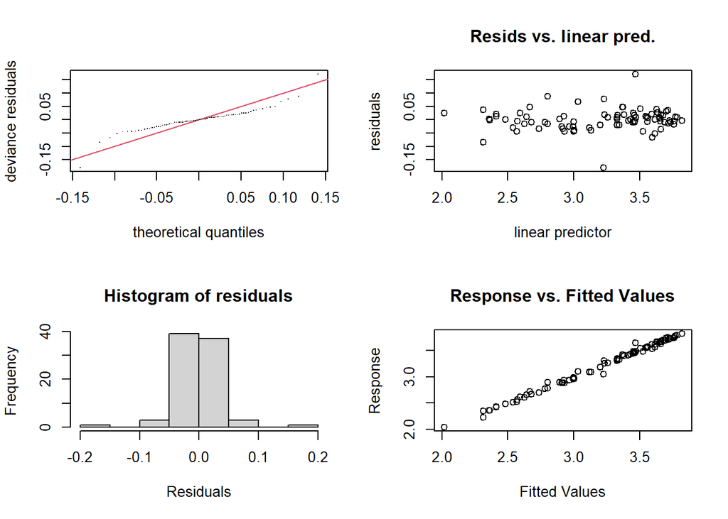

```
##
## Method: REML   Optimizer: outer newton
## full convergence after 7 iterations.
## Gradient range [-6.076513e-08,5.555536e-09]
## (score -52.89797 & scale 0.003143868).
## Hessian positive definite, eigenvalue range [1.222653,43.91196].
## Model rank =  65 / 65
##
## Basis dimension (k) checking results. Low p-value (k-index<1) may
## indicate that k is too low, especially if edf is close to k'.
##
##                          k'   edf k-index p-value
## s(log(conc))           4.00  3.85    0.99    0.44
## s(log(conc),Plant_uo) 60.00 35.96    0.99    0.50
```

```r
gam.check(CO2_mod2)
```

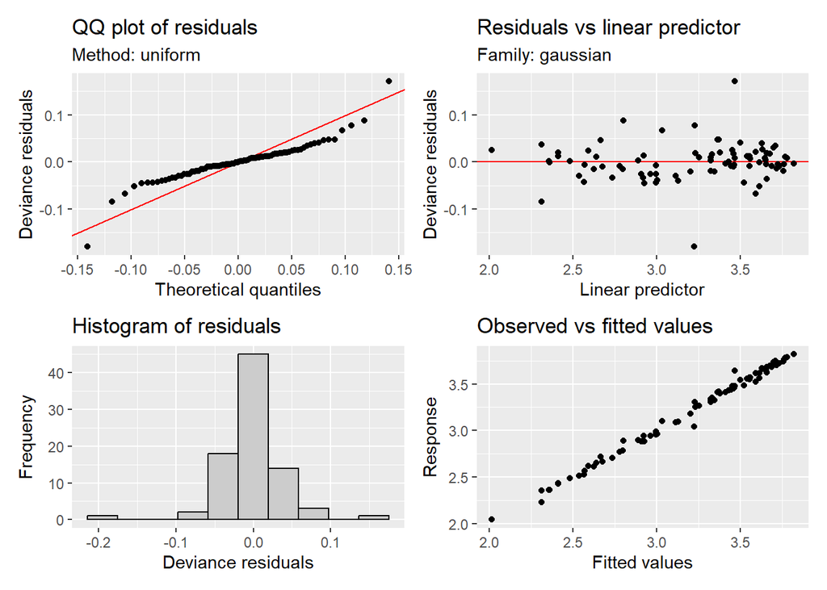

[figure not shown]

```r
appraise(CO2_mod2)
```

Same as second model, but now individual-level smoothers can have *different* wiggliness

[figure not shown]

[figure not shown]

```r
summary(CO2_mod3)
```

```
##
## Family: gaussian
## Link function: identity
##
## Formula:
## log(uptake) ~ s(log(conc), k = 5, m = 2, bs = "tp") + s(log(conc),
##     by = Plant_uo, k = 5, m = 1, bs = "tp") + s(Plant_uo, bs = "re",
##     k = 12)
##
## Parametric coefficients:
##             Estimate Std. Error t value Pr(>|t|)
## (Intercept)  3.20914    0.09497   33.79   <2e-16 ***
## ---
## Signif. codes:  0 '***' 0.001 '**' 0.01 '*' 0.05 '.' 0.1 ' ' 1
##
## Approximate significance of smooth terms:
##                                edf Ref.df       F  p-value
## s(log(conc))             3.853e+00  3.961 358.302  < 2e-16 ***
## s(log(conc)):Plant_uoQn1 1.188e+00  4.000   0.589 0.115639
## s(log(conc)):Plant_uoQn2 2.008e+00  4.000   1.760 0.016329 *
## s(log(conc)):Plant_uoQn3 1.843e-05  4.000   0.000 0.777867
## s(log(conc)):Plant_uoQc1 4.404e-05  4.000   0.000 0.590505
## s(log(conc)):Plant_uoQc3 1.868e+00  4.000   1.172 0.056852 .
## s(log(conc)):Plant_uoQc2 3.608e+00  4.000  15.086  < 2e-16 ***
## s(log(conc)):Plant_uoMn3 2.979e-05  4.000   0.000 0.666830
## s(log(conc)):Plant_uoMn2 4.861e-05  4.000   0.000 0.467567
## s(log(conc)):Plant_uoMn1 2.110e+00  4.000   2.775 0.002063 **
## s(log(conc)):Plant_uoMc2 3.212e+00  4.000   9.381 1.62e-06 ***
## s(log(conc)):Plant_uoMc3 3.305e+00  4.000  11.247  < 2e-16 ***
## s(log(conc)):Plant_uoMc1 2.976e+00  4.000   4.351 0.000658 ***
## s(Plant_uo)              1.096e+01 11.000 263.219  < 2e-16 ***
## ---
## Signif. codes:  0 '***' 0.001 '**' 0.01 '*' 0.05 '.' 0.1 ' ' 1
##
## R-sq.(adj) =  0.987   Deviance explained = 99.2%
## -REML = -60.452  Scale est. = 0.0028672  n = 84
```

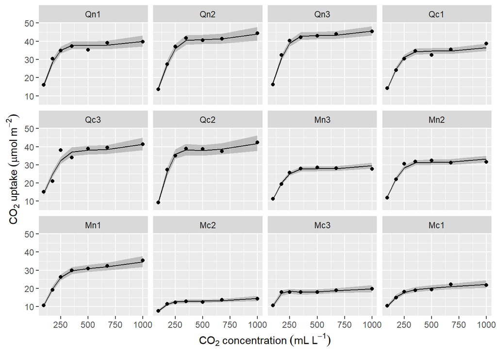

Model AIC comparison

|  | df | AIC |
| --- | --- | --- |
| CO2_mod1 | 16.61168 | -118.6467 |
| CO2_mod2 | 43.24124 | -215.0377 |
| CO2_mod3 | 42.14821 | -216.2503 |